Energy & Infrastructure Risk

# Gulf Cooling Water and Peak Demand

A Gulf Coast power plant uses ocean water to stay cool. If the water gets too warm, it must reduce output sometimes when electricity demand is highest.

Plants were designed assuming water stays below 85°F an assumption from 1970.

Role: Analyst evaluating climate risk for a Gulf Coast utility

01The Problem

02Data & Methods

03Seasonality

04Frequency

05Peak Overlap

06Statistical Evidence

07Recommendations

Ryan Flatley · Dauphin Island, AL · NOAA NDBC + EIA-930 · 2025

Background

## The problem

Gulf Coast power plants use nearby ocean water as a **heat sink** it absorbs waste heat so the plant can keep running at full capacity.

When that water gets too warm, the plant cannot transfer heat fast enough and must **reduce output** to avoid overheating.

When these plants were built in the 1970s, engineers assumed Gulf water would stay below **85°F**. That assumption is now regularly broken.

The dangerous overlap

Gulf water peaks in temperature during late summer the same season when electricity demand is highest due to air conditioning. The plant is constrained exactly when the grid needs it most.

Design assumption (1970)

85°F

Maximum Gulf water temperature the cooling system was built to handle.

What we observed in 2025

92.5°F

Maximum recorded water temperature at Dauphin Island, AL.

Research Question

## Research question

How often does observed Gulf water temperature exceed the **85°F threshold**, and how often do those exceedances coincide with **peak electricity demand**?

This is an operational question not a long-run climate study. Over a near-term planning horizon, how much of a constraint is warm Gulf water, and does it bind at the worst possible moments?

Two things I measured

Exceedance

### Did water temp exceed 85°F?

Yes or no for each hour. When yes, the plant is thermally constrained.

Peak demand

### Was demand in the top 10%?

Yes or no for each hour. When yes, the grid most needs the plant at full output.

The critical hours are when both answers are yes at the same time.

Data & Methods

## How I combined temperature and demand data

Dataset 1 Water Temperature

### NOAA NDBC · Dauphin Island, AL

30-minute sea surface temperature readings for all of 2025. Cleaned, converted °C → °F, and aggregated to hourly means.

**Key variable:** Did the hourly temperature exceed 85°F? (yes / no)

Dataset 2 Electricity Demand

### U.S. EIA-930 · Southern Balancing Authority

Hourly demand in MW, January–July 2025. Time-aligned to match the temperature data.

**Key variable:** Was demand in the top 10% of load hours? (peak / non-peak)

Method

### Logistic Regression

Three models: baseline prevalence, peak-load effect, and month-adjusted to remove seasonal confounding.

Results reported as **odds ratios with 95% confidence intervals**, translated to expected hours and days per year.

Results Seasonality

## Exceedances are a late-summer phenomenon

Share of half-hour readings above 85°F · Dauphin Island, 2025

Jan

0%

Feb

0%

Mar

0%

Apr

0%

May

4%

Jun

56%

Jul

85%

Aug

78%

Sep

25%

Oct

0%

Nov

0%

Dec

0%

**Exceedances are concentrated in June–September.** Max observed: 92.5°F (July). Annual mean: 72.1°F.

Results Frequency

## How often this problem happens

of observed hours

exceeded 85°F in 2025 after aggregating 30-min readings to hourly means

~935

hours per year

~39 days of required reduced-capacity operation under 2025-like conditions

~4,677

hours over 5 years

~195 days of constrained output over a five-year planning horizon

This means plants are operating below full capacity for weeks each year.

Important caveat

These figures are meant to inform planning decisions. They assume near-term conditions mirror 2025. NOAA reports Gulf sea surface temperatures rose ~1°C between 1970 and 2020 meaning the true risk is likely higher than these figures suggest.

Results

## The problem happens at the worst possible time

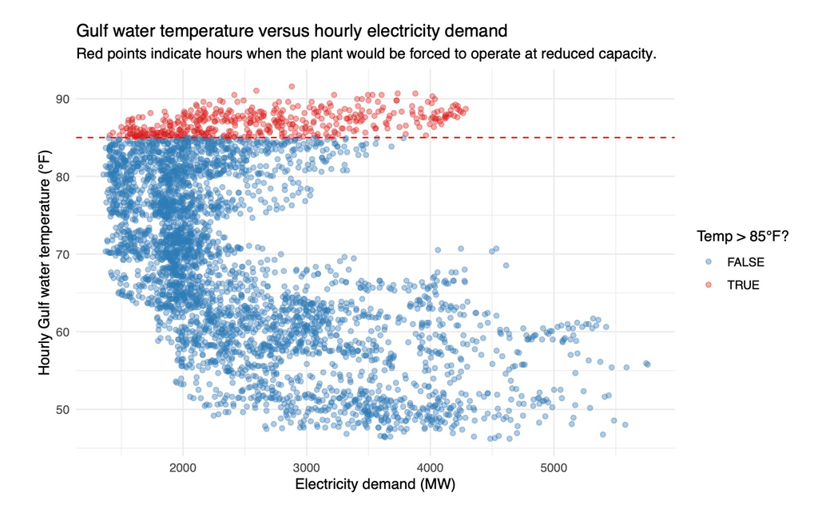

**~99 hours per year** when water exceeded 85°F and demand was in the top 10% simultaneously — and that count excludes July, August, and September entirely.

Recommendations

## Three actionable planning steps

1

#### Capacity and Reserves

Incorporate warm-season derate exposure into resource adequacy assessments. Treat annualized coincident hours as a **lower bound** demand data excludes the three hottest months.

2

#### Maintenance Scheduling

Shift discretionary work toward **shoulder months (October–April)** where exceedance risk is near zero. Avoid planned outages in June–September, especially during peak-demand hours.

3

#### Mitigation Portfolio

Evaluate cooling upgrades, thermal buffering, and demand-side options using a cost–risk screen tied to **restricted-output hours and peak overlap** the quantities this report estimates directly.

Limitations & Future Work

## What the analysis does not claim

Missing months

### The coincidence count is too low

Demand data only run through July 1. July, August, and September the three hottest months are missing from the overlap calculation. Every coincident-hour figure understates the true exposure.

Warming trend

### 2025 may already be optimistic

The frequency projections assume next year looks like 2025. But Gulf water has warmed ~1°C since 1970. The 85°F threshold will be breached more frequently as Gulf water continues to warm.

Thresholds are assumptions

### 85°F and "top 10%" are starting points

These numbers are reasonable defaults, but the actual constraint temperature and peak definition should be validated against the specific plant and market context.

Sensor gaps

### Exceedance rates may be understated

About 2.6% of temperature readings were flagged and removed. If the sensor tended to fail during the hottest conditions, the reported exceedance rates are slightly too low.

Conclusion

## The risk is real and it is growing

~935 hrs/yr above 85°F under 2025 conditions

~99 hrs/yr coincident with peak demand (lower bound)

Thank you I'm happy to take questions.

Ryan Flatley · Sources: NOAA NDBC 2025 · EIA-930 2025 · NOAA NCEI 2023 · Agresti 2013